# Main script Schmits388143

Marie Schmit

2022-12-11

```r
#install.packages("pheatmap")
#install.packages("caret")
```

Load libraries and packages

```r
#Install mlr3extralearners
#devtools::install_local("C:/Programs/R-4.2.2/library/mlr3extralearners-0.5.49")
```

Functions are saved in a dedicated script.

```r
#Source the functions script
source("functions_MSchmit_s388143.R")
source("functions_regression_MSchmits388143.R", echo=TRUE)
```

[output not shown]

# Data preparation and exploratory analysis

Load data files and create datasets.

```r
enose <- read.table("Enose_data-1.csv", sep = ",", header = TRUE, row.names = 1)
sensory <- read.table("Sensory_score-1.csv", sep = ",", header = TRUE, row.names = 1)
counts <- read.table("Bacterial_Counts-1.csv", sep = ",", header = TRUE, row.names = 1)
hplc <- read.table("HPLC_data-1.csv", sep = ",", header = TRUE, row.names = 1)
```

Combine all rows from the csv. Match the samples ID of HPLC and enose data with sensory and bacterial counts data.

```r
# Merge enose and sensory
AllData_enose_sens <- merge_data(enose, sensory, AllData_enose_sens)

# Merge HPLC and sensory
AllData_HPLC_sens <- merge_data(hplc, sensory, AllData_HPLC_sens)

# Merge enose and counts
AllData_enose_counts <- merge_data(enose, counts, AllData_enose_counts)

#Merge HPLC and counts
AllData_HPLC_counts <- merge_data(hplc, counts, AllData_HPLC_counts)

#Merge sensory and counts
AllData_counts_sens <- merge_data(counts, sensory, AllData_counts_sens)

# Sensory values for enose and HPLC
AllData_enose_sens$sensory <- as.factor(AllData_enose_sens$sensory)
AllData_HPLC_sens$sensory <- as.factor(AllData_HPLC_sens$sensory)

sensory_enose <- AllData_enose_sens$sensory
sensory_HPLC <- AllData_HPLC_sens$sensory

# Samples ID
samples <- rownames(AllData_enose_counts)
```

## PCA visualisation

PCA of enose data grouped by sensors.

```r
pca.AllData_enose_sens <- pca_visualisation(pca.AllData_enose_sens, AllData_enose_sens, 3, sensory_enose, "lattice")
```

PCA of HPLC data grouped by sensors.

```r
pca.AllData_HPLC_sens <- pca_visualisation(pca.AllData_HPLC_sens, AllData_HPLC_sens, 3, sensory_HPLC, "lattice")
```

Create 3D PCA plots to better see all features.

```r
pca.AllData_enose_sens <- pca_visualisation(pca.AllData_enose_sens, AllData_enose_sens, 3, sensory_enose, "3d")
pca.AllData_HPLC_sens <- pca_visualisation(pca.AllData_HPLC_sens, AllData_HPLC_sens, 3, sensory_HPLC, "3d")
```

Create biplots of pca model.

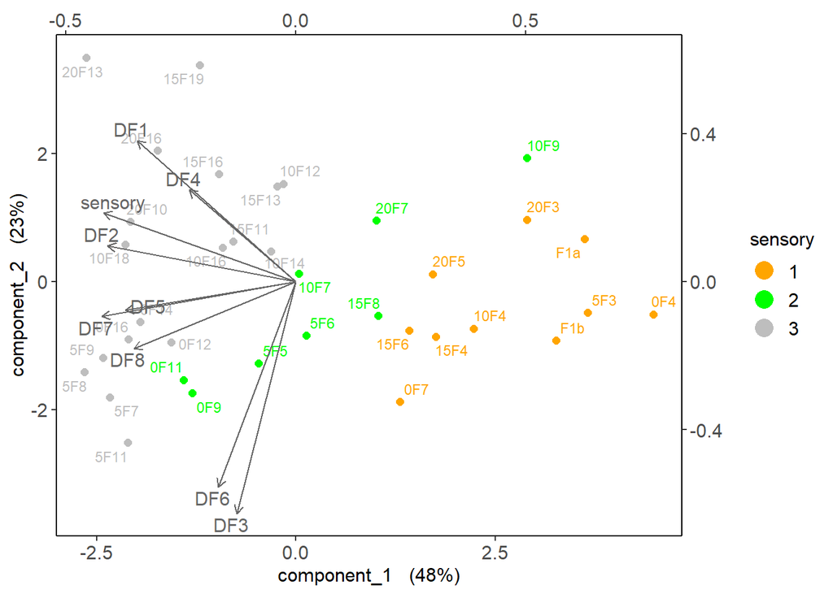

```r
pca_var(pca.AllData_enose_sens, sensory_enose, AllData_enose_sens)
```

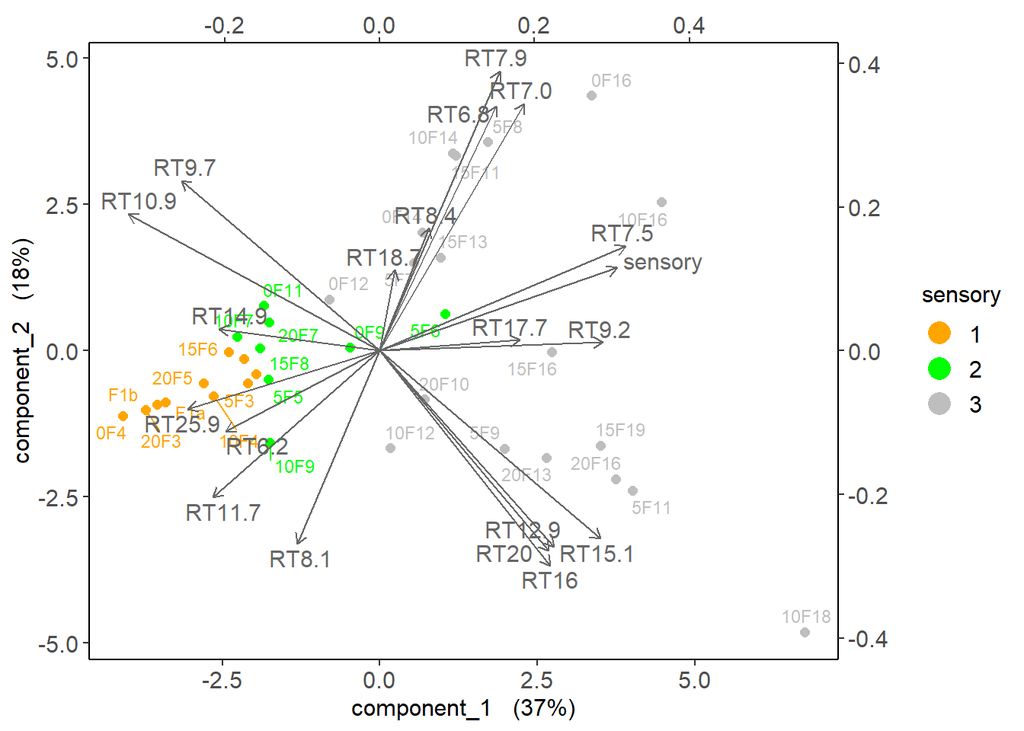

```r
pca_var(pca.AllData_HPLC_sens, sensory_HPLC, AllData_HPLC_sens)
```

HCA analysis

```r
hca_visualisation(AllData_enose_sens)
```

```r
hca_visualisation(AllData_HPLC_sens)
```

```r
pca_visualisation(pca.AllData_enose_sens, AllData_enose_sens, 3, sensory_enose, "lattice")
```

```
##   Eigenvalues for the first 3 principal components, see object$sdev^2:
##       PC1       PC2       PC3
## 4.3249998 2.0905042 0.9466273
##
##   Proportion of  explained variance for the first 3 principal components, see object$prop_expl_var:
##       PC1            PC2            PC3
## 0.4805555      0.2322782      0.1051808
##
##   Cumulative proportion of  explained variance for the first 3 principal components, see object$cum.var:
##       PC1            PC2            PC3
## 0.4805555      0.7128338      0.8180146
##
##   Other available components:
##  --------------------
##   loading vectors: see object$rotation
##   Other functions:
##  --------------------
##   plotIndiv, plot, plotVar, selectVar, biplot
```

## 2. Bacterial counts against time for each temperature and bacteria

```r
# Add temperature and time columns to data frame counts of bacteria
# We remove the samples F1a and F1b because we do not know their temperature
counts_temp_time <- temp_time(AllData_counts_sens[-c(1,2),])
```

For each bacteria: TVC in full line, Pseudomonia in dot line.

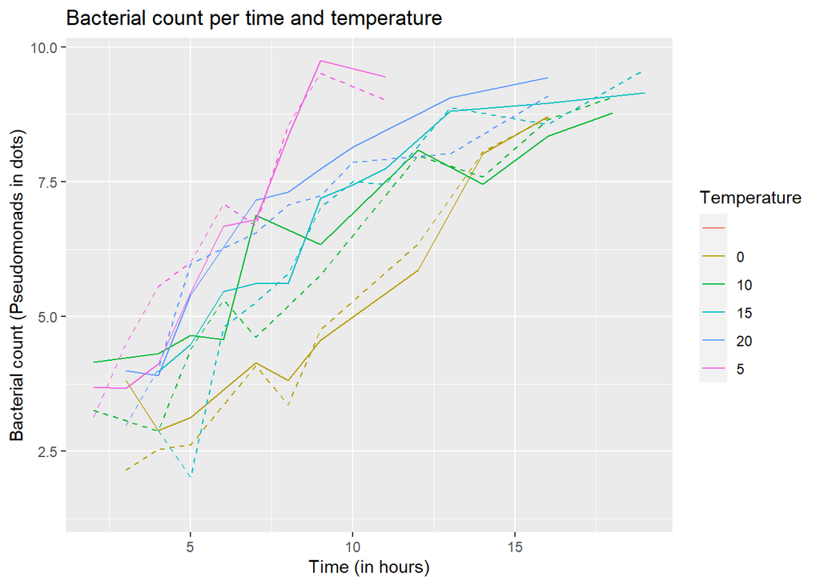

```r
# Plot bacterial counts for each time for TVC
ggplot(data = counts_temp_time,
       aes(x = as.numeric(counts_temp_time$Time),
           y = as.numeric(counts_temp_time$TVC))) +
  #Color the lines by temperature
  geom_line(aes(colour = counts_temp_time$Temperature)) +
  #Add dashed lines for pseudomonads counts
  geom_line(aes(y = as.numeric(counts_temp_time$Pseudomonads),
                colour = counts_temp_time$Temperature), linetype = "dashed") +
  #Add labels
  xlab("Time (in hours)")+
  ylab("Bacterial count (Pseudomonads in dots)")+
  ggtitle("Bacterial count per time and temperature")+
  labs(color = "Temperature")
```

```r
#Save plot
ggsave(filename = paste("Plots/2_CountsPerTime.png"))
```

## 3. Boxplots of bacterial counts for each type of bacteria against sensory score

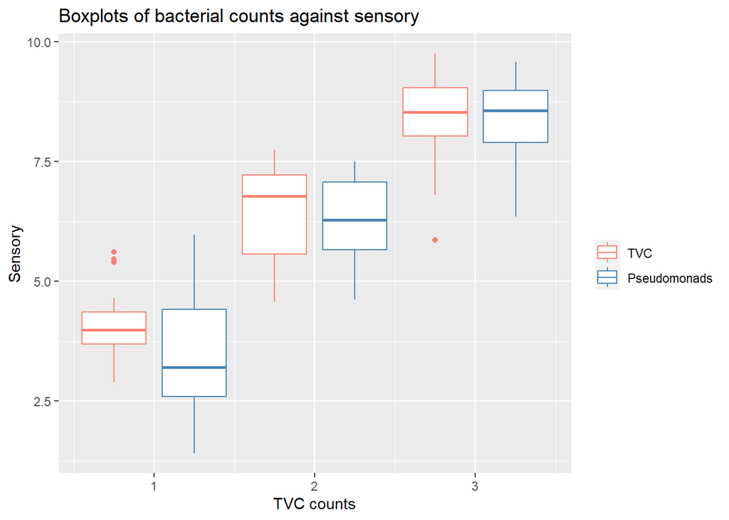

```r
ggplot(data = counts_temp_time, mapping = aes())+
  #Boxes for TVC
  geom_boxplot(aes(group = counts_temp_time$sensory,
                   y = counts_temp_time$TVC, x = counts_temp_time$sensory-0.25,
                   colour = "TVC"), width = 0.4)+
  #Boxes for pseudomonas
  geom_boxplot(aes(group = counts_temp_time$sensory,
                   y = counts_temp_time$Pseudomonads,
                   x = counts_temp_time$sensory+0.25,
                   colour = "Pseudomonads"), width = 0.4)+
  #Create legend
  scale_color_manual("",
                     breaks = c("TVC", "Pseudomonads"),
                     values = c("Salmon", "Steelblue"))+
  # Set axis labels
  xlab("TVC counts")+
  ylab("Sensory")+
  ggtitle("Boxplots of bacterial counts against sensory")
```

```r
#Save plot
ggsave(filename = paste("Plots/3_BoxPlot.png"))
```

# Classification

## Classification method 1: knn

### knn with HCLP

Partition the dataset with 7:3 optimisation Partition the data once for HPLC.

```r
#Use the function Partition to create a partition of data
#Partition data from HPLC and sensory merged
part_HPLC_sens <- partition_data(AllData_HPLC_sens,
                                 AllData_HPLC_sens$sensory, 0.7, 1)
```

## Knn classification

Perform classification for knn on HPLC data merged with sens.

```r
#Optimisation of k without scaling
optimal1 <- knn.optimisation(part_HPLC_sens$trainSet, part_HPLC_sens$testSet,
                             part_HPLC_sens$trainCl, part_HPLC_sens$testCl, 20, c())
```

```
## [1] 1
## Accuracy
##      0.7
## [1] 6
## Accuracy
##      0.8
## [1] 7
## Accuracy
##      0.9
```

```r
optimal1
```

```
## $bestAccuracy
## Accuracy
##      0.9
##
## $bestScale
## NULL
##
## $bestk
## [1] 7
##
## $bestModel
##  [1] 3 1 3 3 1 3 1 3 2 3
## Levels: 1 2 3
##
## $k.accuracies
## Accuracy Accuracy Accuracy Accuracy Accuracy Accuracy Accuracy Accuracy
##      0.7      0.5      0.7      0.6      0.7      0.8      0.9      0.8
## Accuracy Accuracy Accuracy Accuracy Accuracy Accuracy Accuracy Accuracy
##      0.8      0.8      0.8      0.8      0.8      0.8      0.8      0.8
## Accuracy Accuracy Accuracy Accuracy
##      0.8      0.8      0.8      0.5
```

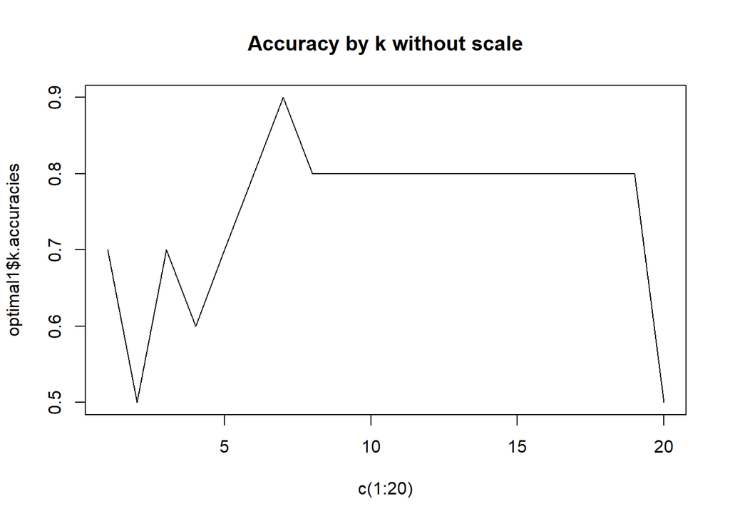

```r
#Plot accuracy against time for non scaled data
plot(x = c(1:20), y = optimal1$k.accuracies, type='l',
           main = "Accuracy by k without scale")
```

```r
#Optimisation of scale methods and k values
optimal2 <- knn.optimisation(part_HPLC_sens$trainSet, part_HPLC_sens$testSet, part_HPLC_sens$trainCl, part_HPLC_sens$testCl, 20, c("center", "scale", "range"))
```

```
## [1] 1
## Accuracy
##      0.7
## [1] 3
## Accuracy
##      0.8
## [1] 8
## Accuracy
##      0.9
```

```r
optimal2
```

```
## $bestAccuracy
## Accuracy
##      0.9
##
## $bestScale
## NULL
##
## $bestk
## [1] 8
##
## $bestModel
##  [1] 3 1 3 3 1 3 1 3 2 3
## Levels: 1 2 3
##
## $k.accuracies
## Accuracy Accuracy Accuracy Accuracy Accuracy Accuracy Accuracy Accuracy
##      0.7      0.6      0.8      0.8      0.7      0.8      0.8      0.9
## Accuracy Accuracy Accuracy Accuracy Accuracy Accuracy Accuracy Accuracy
##      0.8      0.8      0.8      0.8      0.8      0.8      0.8      0.8
## Accuracy Accuracy Accuracy Accuracy Accuracy Accuracy Accuracy Accuracy
##      0.8      0.8      0.8      0.6      0.7      0.5      0.8      0.7
## Accuracy Accuracy Accuracy Accuracy Accuracy Accuracy Accuracy Accuracy
##      0.7      0.8      0.8      0.8      0.8      0.8      0.8      0.8
## Accuracy Accuracy Accuracy Accuracy Accuracy Accuracy Accuracy Accuracy
##      0.8      0.8      0.8      0.8      0.8      0.8      0.8      0.6
## Accuracy Accuracy Accuracy Accuracy Accuracy Accuracy Accuracy Accuracy
##      0.6      0.7      0.6      0.4      0.8      0.9      0.8      0.7
## Accuracy Accuracy Accuracy Accuracy Accuracy Accuracy Accuracy Accuracy
##      0.6      0.6      0.7      0.7      0.7      0.8      0.8      0.8
## Accuracy Accuracy Accuracy Accuracy Accuracy Accuracy Accuracy Accuracy
##      0.7      0.8      0.8      0.7      0.6      0.5      0.5      0.7
## Accuracy Accuracy Accuracy Accuracy Accuracy Accuracy Accuracy Accuracy
##      0.8      0.7      0.8      0.6      0.8      0.7      0.7      0.7
## Accuracy Accuracy Accuracy Accuracy Accuracy Accuracy Accuracy Accuracy
##      0.7      0.7      0.7      0.8      0.8      0.8      0.8      0.7
```

Display the cross table for tunned model (k=7)

```r
cross_table_knn_HPLC <- cross_table_knn(part_HPLC_sens$trainSet,
                                        part_HPLC_sens$testSet,
                                        part_HPLC_sens$trainCl,
                                        part_HPLC_sens$testCl, k = 7)
```

```
##
##
##    Cell Contents
## |-------------------------|
## |                       N |
## |-------------------------|
##
##
## Total Observations in Table:  10
##
##
##              | model.k
##       testCl |         1 |         2 |         3 | Row Total |
## -------------|-----------|-----------|-----------|-----------|
##            1 |         3 |         0 |         0 |         3 |
## -------------|-----------|-----------|-----------|-----------|
##            2 |         0 |         1 |         1 |         2 |
## -------------|-----------|-----------|-----------|-----------|
##            3 |         0 |         0 |         5 |         5 |
## -------------|-----------|-----------|-----------|-----------|
## Column Total |         3 |         1 |         6 |        10 |
## -------------|-----------|-----------|-----------|-----------|
##
##
```

```r
#Display cross table
cross_table_knn_HPLC$cross.table$t
```

```
##    y
## x   1 2 3
##   1 3 0 0
##   2 0 1 1
##   3 0 0 5
```

```r
#Cross table, proportions
cross_table_knn_HPLC$cross.table$prop.tbl
```

```
##    y
## x     1   2   3
##   1 0.3 0.0 0.0
##   2 0.0 0.1 0.1
##   3 0.0 0.0 0.5
```

Partition HPLC for 100 iterations, for tunned model knn (k=7).

```r
#Calculate cumulative mean
cum_mean_HPLC_knn <- cumulative.mean.accuracy(HPLC_sens_run_knn$accuracies)
#Display cumulative means for tuned knn model (k = 7), for 100 iterations
cum_mean_HPLC_knn
```

```
##   [1] 0.8000000 0.6500000 0.7000000 0.7250000 0.7200000 0.6833333 0.7000000
##   [8] 0.6750000 0.6888889 0.6800000 0.6818182 0.6916667 0.7000000 0.7142857
##  [15] 0.7000000 0.7000000 0.7058824 0.7055556 0.7105263 0.7150000 0.7142857
##  [22] 0.7136364 0.7086957 0.7041667 0.7040000 0.7076923 0.7111111 0.7107143
##  [29] 0.7103448 0.7100000 0.7096774 0.7093750 0.7060606 0.7000000 0.7057143
##  [36] 0.7027778 0.7027027 0.7052632 0.7025641 0.7000000 0.6975610 0.7000000
##  [43] 0.7000000 0.7022727 0.7000000 0.6978261 0.7000000 0.6979167 0.6979592
##  [50] 0.7000000 0.7019608 0.7038462 0.7037736 0.7037037 0.7036364 0.7017857
##  [57] 0.7017544 0.7000000 0.7000000 0.7033333 0.7049180 0.7048387 0.7031746
##  [64] 0.7031250 0.7015385 0.7015152 0.7029851 0.7029412 0.7043478 0.7057143
##  [71] 0.7056338 0.7041667 0.7041096 0.7027027 0.7013333 0.7013158 0.7025974
##  [78] 0.7025641 0.7037975 0.7050000 0.7049383 0.7060976 0.7048193 0.7047619
##  [85] 0.7058824 0.7069767 0.7068966 0.7079545 0.7089888 0.7111111 0.7109890
##  [92] 0.7119565 0.7129032 0.7117021 0.7105263 0.7093750 0.7103093 0.7091837
##  [99] 0.7080808 0.7090000
```

### Knn with enose

```r
# Partition data
part_enose_sens <- partition_data(AllData_enose_sens, AllData_enose_sens$sensory, .7, 1)
```

Model tunning

```r
#Optimisation of k without scaling
optimal1 <- knn.optimisation(part_enose_sens$trainSet,
                             part_enose_sens$testSet,
                             part_enose_sens$trainCl,
                             part_enose_sens$testCl, 20, c())
```

```
## [1] 1
## Accuracy
##      0.9
## [1] 3
## Accuracy
##        1
```

```r
#Accuracy of optimal model for knn, enose, without pre scaling
optimal1$bestAccuracy
```

```
## Accuracy
##        1
```

```r
#k value of optimal model
optimal1$bestk
```

```
## [1] 3
```

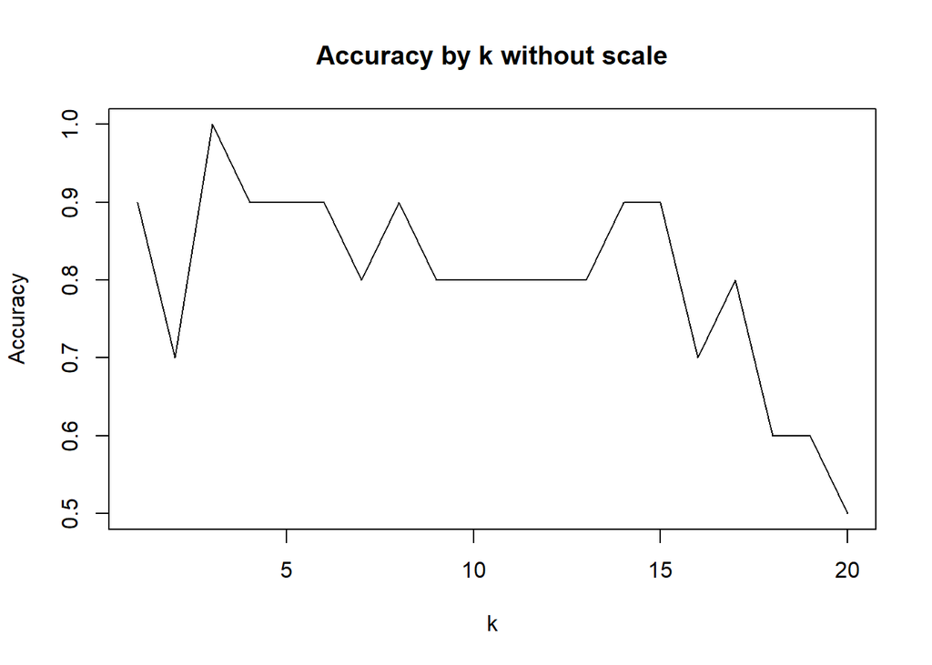

```r
#Plot accuracy against time for non scaled data
plot(x = c(1:20), y = optimal1$k.accuracies, type='l',
     main = "Accuracy by k without scale",
     xlab = "k",
     ylab = "Accuracy")
```

```r
#Optimisation of scale methods and k values
optimal2 <- knn.optimisation(part_enose_sens$trainSet,
                             part_enose_sens$testSet,
                             part_enose_sens$trainCl,
                             part_enose_sens$testCl,
                             20, c("center", "scale", "range"))
```

```
## [1] 1
## Accuracy
##      0.9
## [1] 3
## Accuracy
##        1
```

```r
#Accuracy of optimal model for knn, enose, with scaling
optimal2$bestAccuracy
```

```
## Accuracy
##        1
```

```r
#k of optimal model, enose, with prescaling
optimal2$bestk
```

```
## [1] 3
```

```r
#SCale of optimal model, enose, with prescaling
optimal2$bestScale
```

Partition enose for 100 iterations, for tunned model knn (k=3).

Calculate cumulative means of previous model for 100 iterations

```r
#Calculate cumulative mean
cum_mean_enose_knn <- cumulative.mean.accuracy(enose_sens_run_knn$accuracies)
print(cum_mean_enose_knn)
```

```
##   [1] 0.8000000 0.8500000 0.7666667 0.7750000 0.8000000 0.7833333 0.7857143
##   [8] 0.7875000 0.7888889 0.7900000 0.8000000 0.8000000 0.8000000 0.7857143
##  [15] 0.7866667 0.7875000 0.7941176 0.7944444 0.8000000 0.8050000 0.8095238
##  [22] 0.8090909 0.8043478 0.8041667 0.8080000 0.8076923 0.8074074 0.8035714
##  [29] 0.8034483 0.8000000 0.8000000 0.7875000 0.7909091 0.7882353 0.7914286
##  [36] 0.7888889 0.7891892 0.7921053 0.7923077 0.7900000 0.7878049 0.7904762
##  [43] 0.7860465 0.7886364 0.7888889 0.7891304 0.7914894 0.7895833 0.7918367
##  [50] 0.7900000 0.7901961 0.7903846 0.7924528 0.7925926 0.7945455 0.7982143
##  [57] 0.8000000 0.7982759 0.7983051 0.7933333 0.7934426 0.7935484 0.7952381
##  [64] 0.7953125 0.7938462 0.7954545 0.7955224 0.7955882 0.7942029 0.7957143
##  [71] 0.7929577 0.7930556 0.7931507 0.7932432 0.7920000 0.7907895 0.7922078
##  [78] 0.7923077 0.7911392 0.7925000 0.7925926 0.7939024 0.7927711 0.7940476
##  [85] 0.7929412 0.7930233 0.7931034 0.7909091 0.7910112 0.7922222 0.7901099
##  [92] 0.7902174 0.7892473 0.7904255 0.7905263 0.7916667 0.7907216 0.7918367
##  [99] 0.7909091 0.7910000
```

## Classification method 2: svm - rd

### svm-rd with HCLP

```r
#List of kernels to test for calssification
kerList <- as.array(c('vanilladot', 'polydot', 'rbfdot', 'tanhdot'))

#Optimisation of the model: test of kernels from the list
optimal_svm_hplc <- svm.optimisation(part_HPLC_sens$trainSet,
                                     part_HPLC_sens$testSet,
                                     part_HPLC_sens$trainCl,
                                     part_HPLC_sens$testCl, kerList)
```

```
##
##
##    Cell Contents
## |-------------------------|
## |                       N |
## |-------------------------|
##
##
## Total Observations in Table:  10
##
##
##              | kernel.predicted
##       testCl |         1 |         2 |         3 | Row Total |
## -------------|-----------|-----------|-----------|-----------|
##            1 |         1 |         2 |         0 |         3 |
## -------------|-----------|-----------|-----------|-----------|
##            2 |         1 |         0 |         1 |         2 |
## -------------|-----------|-----------|-----------|-----------|
##            3 |         1 |         0 |         4 |         5 |
## -------------|-----------|-----------|-----------|-----------|
## Column Total |         3 |         2 |         5 |        10 |
## -------------|-----------|-----------|-----------|-----------|
##
##
##
##
##    Cell Contents
## |-------------------------|
## |                       N |
## |-------------------------|
##
##
## Total Observations in Table:  10
##
##
##              | kernel.predicted
##       testCl |         1 |         3 | Row Total |
## -------------|-----------|-----------|-----------|
##            1 |         3 |         0 |         3 |
## -------------|-----------|-----------|-----------|
##            2 |         1 |         1 |         2 |
## -------------|-----------|-----------|-----------|
##            3 |         1 |         4 |         5 |
## -------------|-----------|-----------|-----------|
## Column Total |         5 |         5 |        10 |
## -------------|-----------|-----------|-----------|
##
##
```

```r
#Accuracy, kernel, cross table and confusion matrix of tuned model
print("Accuracy:")
```

```
## [1] "Accuracy:"
```

```r
optimal_svm_hplc$bestAccuracy
```

```
## Accuracy
##      0.7
```

```r
print("Kernel:")
```

```
## [1] "Kernel:"
```

```r
optimal_svm_hplc$bestKernel
```

```
## [1] "rbfdot"
```

```r
print("Cross table:")
```

```
## [1] "Cross table:"
```

```r
optimal_svm_hplc$bestCrossTable$t
```

```
##    y
## x   1 3
##   1 3 0
##   2 1 1
##   3 1 4
```

```r
print("Confusion matrix:")
```

```
## [1] "Confusion matrix:"
```

```r
optimal_svm_hplc$bestConfusionMatrix
```

```
## Confusion Matrix and Statistics
##
##           Reference
## Prediction 1 2 3
##          1 3 1 1
##          2 0 0 0
##          3 0 1 4
##
## Overall Statistics
##
##                Accuracy : 0.7
##                  95% CI : (0.3475, 0.9333)
##     No Information Rate : 0.5
##     P-Value [Acc > NIR] : 0.1719
##
##                   Kappa : 0.5
##
##  Mcnemar's Test P-Value : 0.3916
##
## Statistics by Class:
##
##                      Class: 1 Class: 2 Class: 3
## Sensitivity            1.0000      0.0      0.8
## Specificity            0.7143      1.0      0.8
## Pos Pred Value         0.6000      NaN      0.8
## Neg Pred Value         1.0000      0.8      0.8
## Prevalence             0.3000      0.2      0.5
## Detection Rate         0.3000      0.0      0.4
## Detection Prevalence   0.5000      0.0      0.5
## Balanced Accuracy      0.8571      0.5      0.8
```

```r
#Calculate cumulative mean of previous model
cum_mean_HPLC_svm <- cumulative.mean.accuracy(HPLC_sens_run_svm$accuracies)
#Print cumulative mean accuracy of 100th iteration
cum_mean_HPLC_svm[100]
```

```
## [1] 0.789
```

### svm-rd with enose

```r
#List of kernels to test for classification
kerList <- as.array(c('vanilladot', 'polydot', 'rbfdot', 'tanhdot'))

#Optimisation of the model: test of kernels from the list
optimal_svm_enose <- svm.optimisation(part_enose_sens$trainSet, part_enose_sens$testSet, part_enose_sens$trainCl, part_enose_sens$testCl, kerList)
```

```
##
##
##    Cell Contents
## |-------------------------|
## |                       N |
## |-------------------------|
##
##
## Total Observations in Table:  10
##
##
##              | kernel.predicted
##       testCl |         1 |         3 | Row Total |
## -------------|-----------|-----------|-----------|
##            1 |         3 |         0 |         3 |
## -------------|-----------|-----------|-----------|
##            2 |         1 |         1 |         2 |
## -------------|-----------|-----------|-----------|
##            3 |         1 |         4 |         5 |
## -------------|-----------|-----------|-----------|
## Column Total |         5 |         5 |        10 |
## -------------|-----------|-----------|-----------|
##
##
##
##
##    Cell Contents
## |-------------------------|
## |                       N |
## |-------------------------|
##
##
## Total Observations in Table:  10
##
##
##              | kernel.predicted
##       testCl |         1 |         2 |         3 | Row Total |
## -------------|-----------|-----------|-----------|-----------|
##            1 |         3 |         0 |         0 |         3 |
## -------------|-----------|-----------|-----------|-----------|
##            2 |         0 |         1 |         1 |         2 |
## -------------|-----------|-----------|-----------|-----------|
##            3 |         0 |         0 |         5 |         5 |
## -------------|-----------|-----------|-----------|-----------|
## Column Total |         3 |         1 |         6 |        10 |
## -------------|-----------|-----------|-----------|-----------|
##
##
```

```r
#Print accuracy and kernel of tuned model
optimal_svm_enose$bestAccuracy
```

```
## Accuracy
##      0.9
```

```r
optimal_svm_enose$bestKernel
```

```
## [1] "rbfdot"
```

```r
#Calculate cumulative mean
cum_mean_enose_svm <- cumulative.mean.accuracy(enose_sens_run_svm$accuracies)
#Print cumulative mean accuracy of 100th iteration
cum_mean_enose_svm[100]
```

```
## [1] 0.789
```

## Classification method 3: Random Forest

### RF with data HPLC

Model building: Create model task

```r
#Create a learner
rf_class_learner_HPLC <- rf_class_learner(AllData_HPLC_sens)
rf_class_learner_HPLC$rf_task
```

```
## <TaskClassif:AllData> (36 x 20)
## * Target: sensory
## * Properties: multiclass
## * Features (19):
##   - dbl (19): RT10.9, RT11.7, RT12.9, RT14.9, RT15.1, RT16, RT17.7,
##     RT18.7, RT20, RT25.9, RT6.2, RT6.8, RT7.0, RT7.5, RT7.9, RT8.1,
##     RT8.4, RT9.2, RT9.7
```

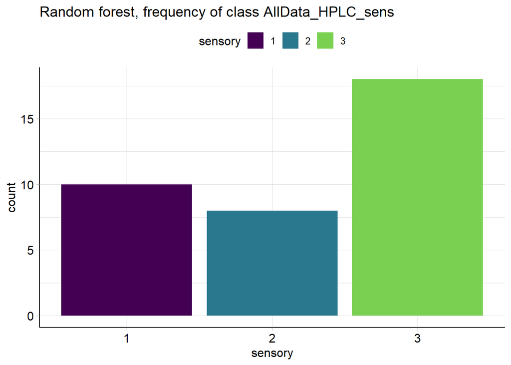

```r
#Check the number of elements for each sensory
rf_class_learner_HPLC$plt
```

Model tunning

```r
#List of hypoparameters
rf_class_learner_HPLC$learner$param_set$ids()
```

```
##  [1] "ntree"       "mtry"        "replace"     "classwt"     "cutoff"
##  [6] "strata"      "sampsize"    "nodesize"    "maxnodes"    "importance"
## [11] "localImp"    "proximity"   "oob.prox"    "norm.votes"  "do.trace"
## [16] "keep.forest" "keep.inbag"  "predict.all" "nodes"
```

```r
#Pefrom tuning for hplc
rf_tuning_HPLC <- rf_tuning(ntree_min = 200, ntree_max = 500,
                            mtry_min = 2, mtry_max = 19,
                            nodesize_min = 1, nodesize_max = 5,
                            maxnodes_min = 2, maxnodes_max = 20,
                            nb_evaluation = 20, part_ratio = .7,
                            task_rf = rf_class_learner_HPLC$rf_task,
                            AllData = AllData_HPLC_sens
                            )
```

[output not shown]

[output not shown]

[output cut: 49 more lines]

[output not shown]

```
## INFO  [15:06:42.836] [mlr3] Finished benchmark
## INFO  [15:06:42.929] [bbotk] Result of batch 5:
## INFO  [15:06:42.931] [bbotk]  ntree mtry nodesize maxnodes classif.acc warnings errors runtime_learners
## INFO  [15:06:42.931] [bbotk]    275    2        1       20   0.8009259        0      0             0.06
## INFO  [15:06:42.931] [bbotk]    425    6        2        6   0.7638889        0      0             0.07
## INFO  [15:06:42.931] [bbotk]    500    2        3       20   0.8009259        0      0             0.03
## INFO  [15:06:42.931] [bbotk]    500   15        5        6   0.8009259        0      0             0.06
## INFO  [15:06:42.931] [bbotk]                                 uhash
## INFO  [15:06:42.931] [bbotk]  5a927533-3f00-45a8-98fa-d10d9a4e00dc
## INFO  [15:06:42.931] [bbotk]  befe95c5-e732-42e0-b874-3c40ae1d9ab4
## INFO  [15:06:42.931] [bbotk]  88fbdff9-f321-4082-9a8a-e7b0288c2c62
## INFO  [15:06:42.931] [bbotk]  c7907e3c-b262-4d31-88e4-642cbc24378f
## INFO  [15:06:42.942] [bbotk] Finished optimizing after 20 evaluation(s)
## INFO  [15:06:42.943] [bbotk] Result:
## INFO  [15:06:42.946] [bbotk]  ntree mtry nodesize maxnodes learner_param_vals  x_domain classif.acc
## INFO  [15:06:42.946] [bbotk]    350    2        1        6          <list[4]> <list[4]>   0.8009259
```

Best hyperparameters for tuning rf learner, HPLC

```r
rf_tuning_HPLC$instance$result_learner_param_vals
```

```
## $ntree
## [1] 350
##
## $mtry
## [1] 2
##
## $nodesize
## [1] 1
##
## $maxnodes
## [1] 6
```

Build final model with the tuned parameters for HPLC, rf

```r
learner_tun_HPLC <- built_model(learner_tun = rf_tuning_HPLC$learner_tun,
                                instance = rf_tuning_HPLC$instance,
                                task_train = rf_tuning_HPLC$task_train)
#Print tuned model
learner_tun_HPLC$model
```

```
##
## Call:
##  randomForest(formula = formula, data = data, classwt = classwt,      cutoff = cutoff, ntree = 350L, mtry = 2L, nodesize = 1L,      maxnodes = 6L)
##                Type of random forest: classification
##                      Number of trees: 350
## No. of variables tried at each split: 2
##
##         OOB estimate of  error rate: 23.08%
## Confusion matrix:
##   1 2  3 class.error
## 1 6 1  0  0.14285714
## 2 2 2  2  0.66666667
## 3 0 1 12  0.07692308
```

Test final model

```r
test_HPLC_perf <- rf_test(rf_class_learner_HPLC$rf_task,
                          learner_tun_HPLC,
                          part_ratio = .7,
                          split = rf_tuning_HPLC$split,
                          title = "HPLC")
#Print accuracy
test_HPLC_perf$accuracy
```

```
## classif.acc
##         0.7
```

```r
#Print confusion matrix
test_HPLC_perf$conf_matr
```

```
##         truth
## response 1 2 3
##        1 2 2 0
##        2 1 0 0
##        3 0 0 5
```

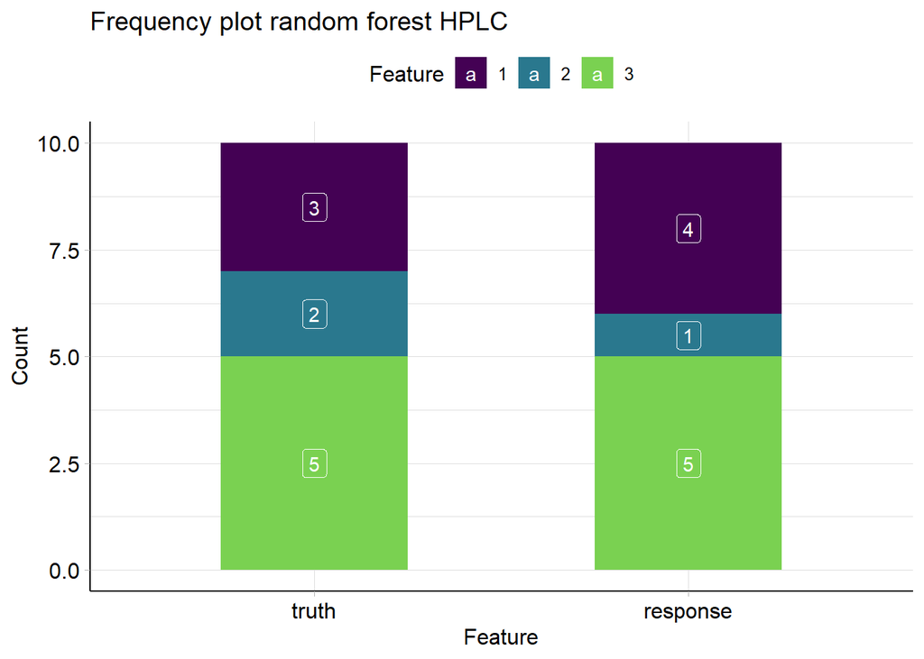

```r
#Plot performances
test_HPLC_perf$plt
```

Classification with rf, 100 iterations, HPLC

```r
#With 100 iterations, train and test the tuned model
rf_accuracies_HPLC <- run_rf(rf_class_learner_HPLC$rf_task,
                             times = 100,
                             learner = learner_tun_HPLC,
                             ratio = .7)
#Calculate cumulative means accuracies
cum_mean_HPLC_rf <- cumulative.mean.accuracy(rf_accuracies_HPLC$accuracies)
#Cumulative mean accuracy of 100th iteration:
cum_mean_HPLC_rf[100]
```

```
## [1] 0.804
```

### RF with enose

Model building: create model task

```r
#Create a learner for rf with enose data
rf_class_learner_enose <- rf_class_learner(AllData_enose_sens)
rf_class_learner_enose$rf_task
```

```
## <TaskClassif:AllData> (36 x 9)
## * Target: sensory
## * Properties: multiclass
## * Features (8):
##   - dbl (8): DF1, DF2, DF3, DF4, DF5, DF6, DF7, DF8
```

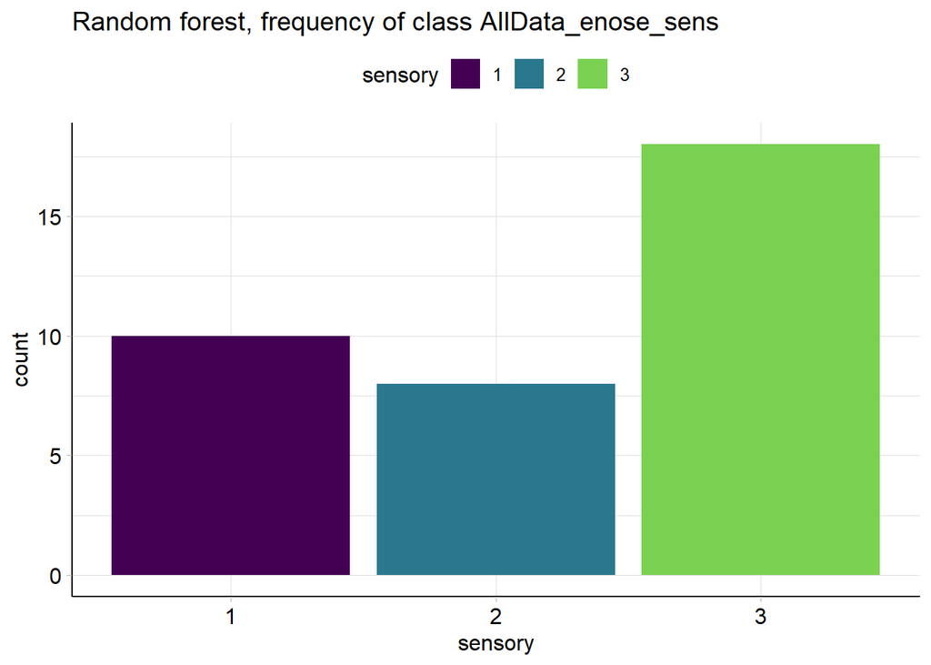

```r
#Check the number of elements for each sensory
rf_class_learner_enose$plt
```

Model tunning, rf with enose data

```r
#List of hypoparameters
rf_class_learner_enose$learner$param_set$ids()
```

```
##  [1] "ntree"       "mtry"        "replace"     "classwt"     "cutoff"
##  [6] "strata"      "sampsize"    "nodesize"    "maxnodes"    "importance"
## [11] "localImp"    "proximity"   "oob.prox"    "norm.votes"  "do.trace"
## [16] "keep.forest" "keep.inbag"  "predict.all" "nodes"
```

```r
#Perfrom tuning for rf, enose
rf_tuning_enose <- rf_tuning(ntree_min = 200, ntree_max = 500,
                            mtry_min = 2, mtry_max = 8,
                            nodesize_min = 1, nodesize_max = 5,
                            maxnodes_min = 2, maxnodes_max = 20,
                            nb_evaluation = 20, part_ratio = .7,
                            task_rf = rf_class_learner_enose$rf_task,
                            AllData = AllData_enose_sens
                      )
```

[output not shown]

[output not shown]

[output cut: 49 more lines]

[output not shown]

```
## INFO  [15:06:52.115] [mlr3] Finished benchmark
## INFO  [15:06:52.207] [bbotk] Result of batch 5:
## INFO  [15:06:52.209] [bbotk]  ntree mtry nodesize maxnodes classif.acc warnings errors runtime_learners
## INFO  [15:06:52.209] [bbotk]    275    2        1       20   0.7268519        0      0             0.06
## INFO  [15:06:52.209] [bbotk]    425    3        2        6   0.7268519        0      0             0.00
## INFO  [15:06:52.209] [bbotk]    500    2        3       20   0.7638889        0      0             0.00
## INFO  [15:06:52.209] [bbotk]    500    7        5        6   0.5787037        0      0             0.03
## INFO  [15:06:52.209] [bbotk]                                 uhash
## INFO  [15:06:52.209] [bbotk]  c4662c2a-ec10-4df9-becd-90224b251260
## INFO  [15:06:52.209] [bbotk]  6ece809c-e739-4928-81c4-217808b54a57
## INFO  [15:06:52.209] [bbotk]  2545796a-9100-4e59-b64b-293eddca7449
## INFO  [15:06:52.209] [bbotk]  3f1d36a6-d5f9-4f41-b238-f7f657b27698
## INFO  [15:06:52.215] [bbotk] Finished optimizing after 20 evaluation(s)
## INFO  [15:06:52.216] [bbotk] Result:
## INFO  [15:06:52.217] [bbotk]  ntree mtry nodesize maxnodes learner_param_vals  x_domain classif.acc
## INFO  [15:06:52.217] [bbotk]    500    2        3       20          <list[4]> <list[4]>   0.7638889
```

Best hyperparameters

```r
#Display optimised hyperparameters
rf_tuning_enose$instance$result_learner_param_vals
```

```
## $ntree
## [1] 500
##
## $mtry
## [1] 2
##
## $nodesize
## [1] 3
##
## $maxnodes
## [1] 20
```

Build final model with the tuned parameters

```r
learner_tun_enose <- built_model(learner_tun = rf_tuning_enose$learner_tun,
                                 instance = rf_tuning_enose$instance,
                                 task_train = rf_tuning_enose$task_train)
#Display tuned learner
learner_tun_enose$model
```

```
##
## Call:
##  randomForest(formula = formula, data = data, classwt = classwt,      cutoff = cutoff, ntree = 500L, mtry = 2L, nodesize = 3L,      maxnodes = 20L)
##                Type of random forest: classification
##                      Number of trees: 500
## No. of variables tried at each split: 2
##
##         OOB estimate of  error rate: 19.23%
## Confusion matrix:
##   1 2  3 class.error
## 1 6 1  0   0.1428571
## 2 2 2  2   0.6666667
## 3 0 0 13   0.0000000
```

Test final model, tuned rf for enose data

```r
test_enose_perf <- rf_test(rf_class_learner_enose$rf_task,
                           learner_tun_enose,
                           part_ratio = .7,
                           split = rf_tuning_enose$split,
                           title = "enose")
#Print accuracy
test_enose_perf$accuracy
```

```
## classif.acc
##         0.7
```

```r
#Print confusion matrix
test_enose_perf$conf_matr
```

```
##         truth
## response 1 2 3
##        1 3 1 0
##        2 0 0 1
##        3 0 1 4
```

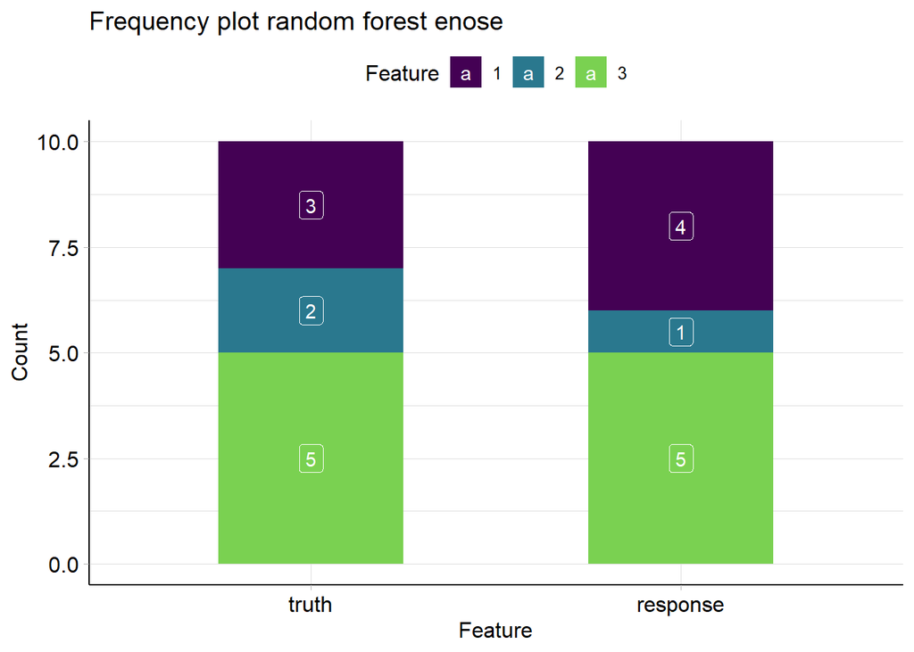

```r
#Plot performances
test_enose_perf$plt
```

100 iterations, tuned rf for enose data

```r
#With 100 iterations, train and test the tunned model
rf_accuracies_enose <- run_rf(rf_class_learner_enose$rf_task,
                              times = 100,
                              learner = learner_tun_enose,
                              ratio = .7)
#Calculate cumulative means accuracies
cum_mean_enose_rf <- cumulative.mean.accuracy(rf_accuracies_enose$accuracies)
#Cumulative mean accuracy for 100th iteration
cum_mean_enose_rf[100]
```

```
## [1] 0.74
```

## 1. Bar plot of all cumulative mean accuracies, for 100 iterations

```r
#Create and save cumulative means plot for enose
cumulative_plot(cum_mean_enose_knn, cum_mean_enose_rf, cum_mean_enose_svm, "enose")
#Create and save cumulative means plot for HPLC
cumulative_plot(cum_mean_HPLC_knn, cum_mean_HPLC_rf, cum_mean_HPLC_svm, "HPLC")
```

## 2. Number and proportion of misclassified samples

```r
#Barplot of misclassifications proportion per class
list_methods <- list(HPLC_sens_run_knn$misclas$mis_prop_sum,
                  HPLC_sens_run_svm$misclas$mis_prop_sum,
                  rf_accuracies_HPLC$misclas$mis_prop_sum,
                  enose_sens_run_knn$misclas$mis_prop_sum,
                  enose_sens_run_svm$misclas$mis_prop_sum,
                  rf_accuracies_enose$misclas$mis_prop_sum
                  )
list_proportions <- c("HPLC_knn", "HPLC_svm", "HPLC_rf",
                      "enose_knn", "enose_svm", "enose_rf")

#Create and save barplots for every dataset and method
misclassified_proportion_barplot(list_methods, list_proportions)
```

##3. Importance of each variable for the prediction for one iteration Variable importance for knn

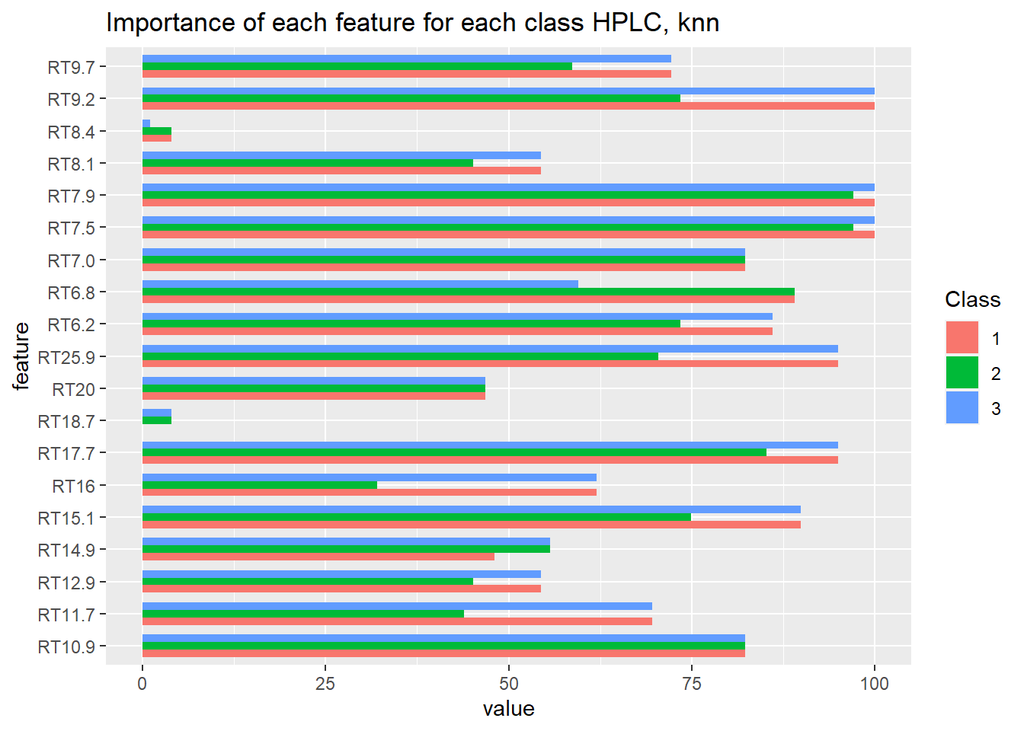

```r
#Calculate the importance for knn
#HPLC data importances, kn
knn_var_importance_HPLC <- var_importance(AllData_HPLC_sens,
                                          AllData_HPLC_sens$sensory, .7, 1,
                                          sensory~., method = "knn",
                                          tuneGrid = expand.grid(k = 1:20))
#Importance plot HPLC data, knn
importance_plot(knn_var_importance_HPLC$Imp, "HPLC, knn")
```

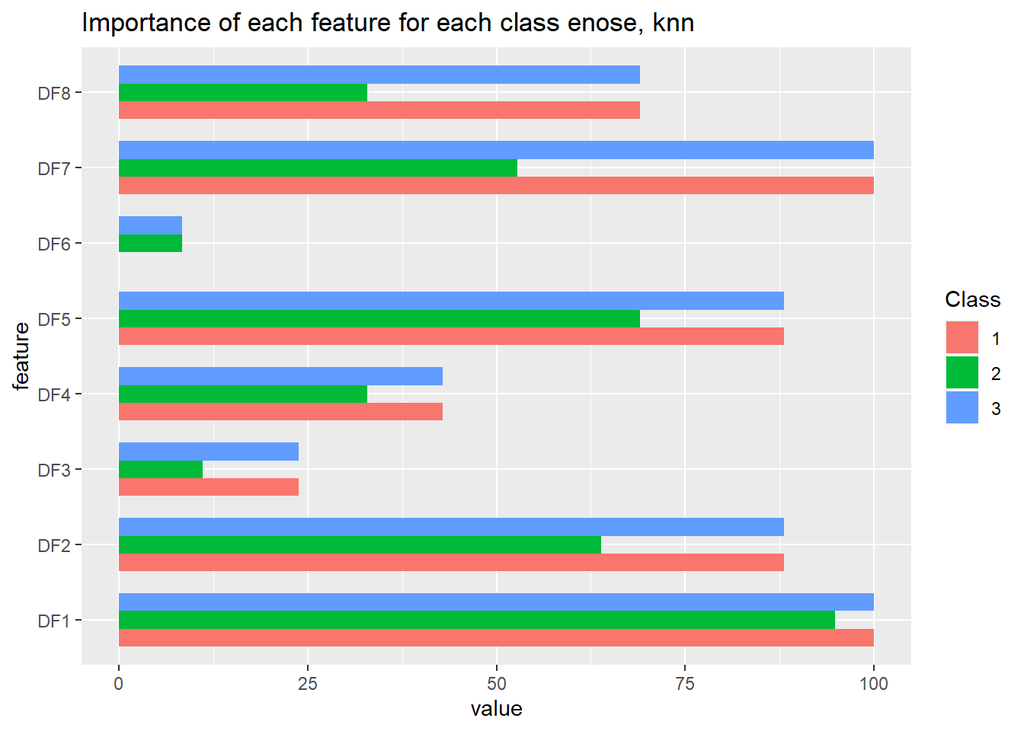

```r
#Enose data importances, knn
knn_var_importance_enose <- var_importance(AllData_enose_sens,
                                           AllData_enose_sens$sensory, .7, 1,
                                           sensory~., method = "knn",
                                           tuneGrid = expand.grid(k = 1:20))
#Importance plot enose data, knn
importance_plot(knn_var_importance_enose$Imp, "enose, knn")
```

Variable importance for svm

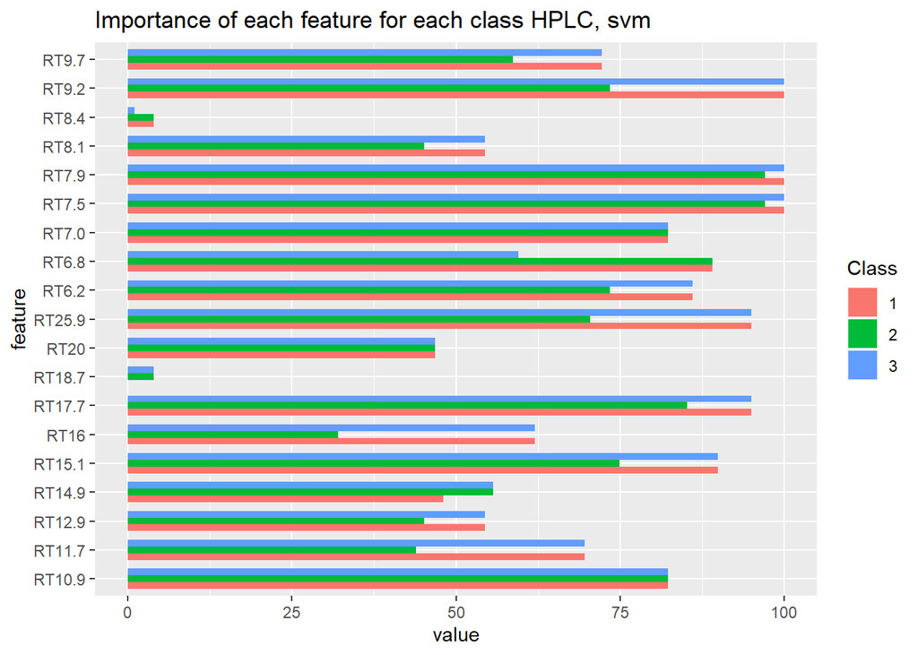

```r
#Calculate the importance for svm
#HPLC data importances, svm
svm_var_importance_HPLC <- var_importance(AllData_HPLC_sens,
                                          AllData_HPLC_sens$sensory, .7, 1,
                                          sensory~., method = "svmRadial",
                                          tuneGrid = NULL)
#Importance plot, HPLC, svm
importance_plot(svm_var_importance_HPLC$Imp, "HPLC, svm")
```

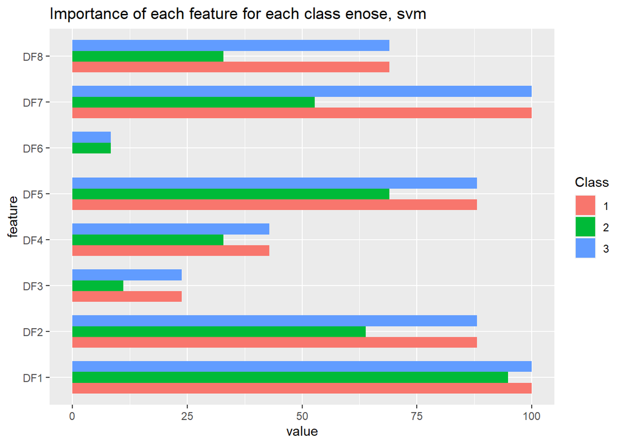

```r
#Enose data importances, svm
svm_var_importance_enose <- var_importance(AllData_enose_sens,
                                           AllData_enose_sens$sensory, .7, 1,
                                           sensory~., method = "svmRadial",
                                           tuneGrid = NULL)
#Importance plot, enose, svm
importance_plot(svm_var_importance_enose$Imp, "enose, svm")
```

Overall variable importance for random forest

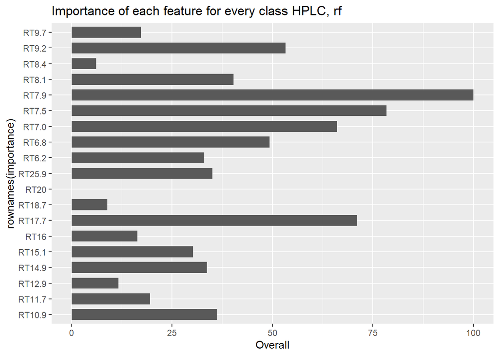

```r
#Return table of variables importance for HPLC
overall_rf_var_importance_HPLC <- var_importance(AllData_HPLC_sens,
                                          AllData_HPLC_sens$sensory, .7, 1,
                                          sensory~., method = "rf",
                                          tuneGrid = expand.grid(mtry = 2:19))
#Importance plot
overall_importance_plot(overall_rf_var_importance_HPLC$Imp, "HPLC, rf")
```

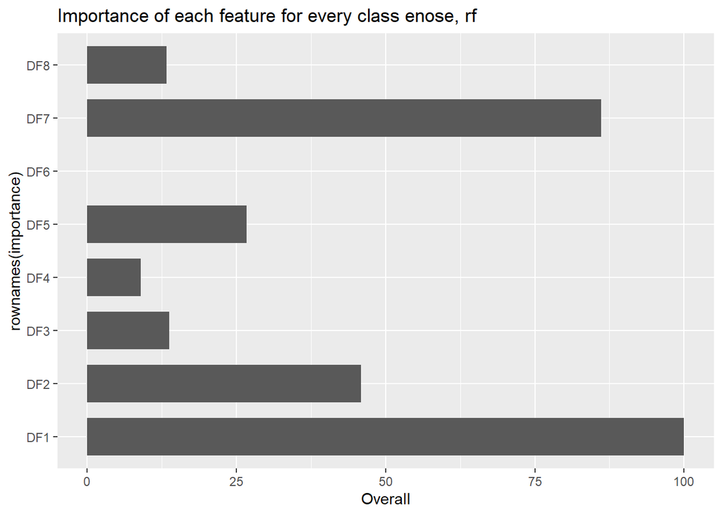

```r
#Variables importance for enose
overall_rf_var_importance_enose <- var_importance(AllData_enose_sens,
                                             AllData_enose_sens$sensory,0.7, 1,
                                             sensory~., method = "rf",
                                             tuneGrid = expand.grid(mtry = 2:8))
#Importance plot
overall_importance_plot(overall_rf_var_importance_enose$Imp, "enose, rf")
```

Variable importance for random forest

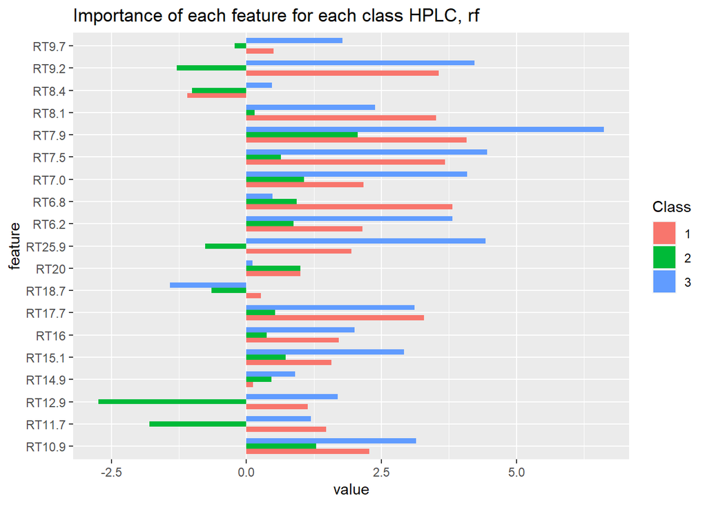

```r
#Return table of variables importance for HPLC
rf_var_importance_HPLC <- rf_var_importance(AllData_HPLC_sens,
                                            AllData_HPLC_sens$sensory,
                                            0.7, 1,
                                            ntree = 200L,
                                            mtry = 2L,
                                            nodesize = 2L,
                                            maxnodes = 20L)
#Importance plot
importance_plot(rf_var_importance_HPLC, "HPLC, rf")
```

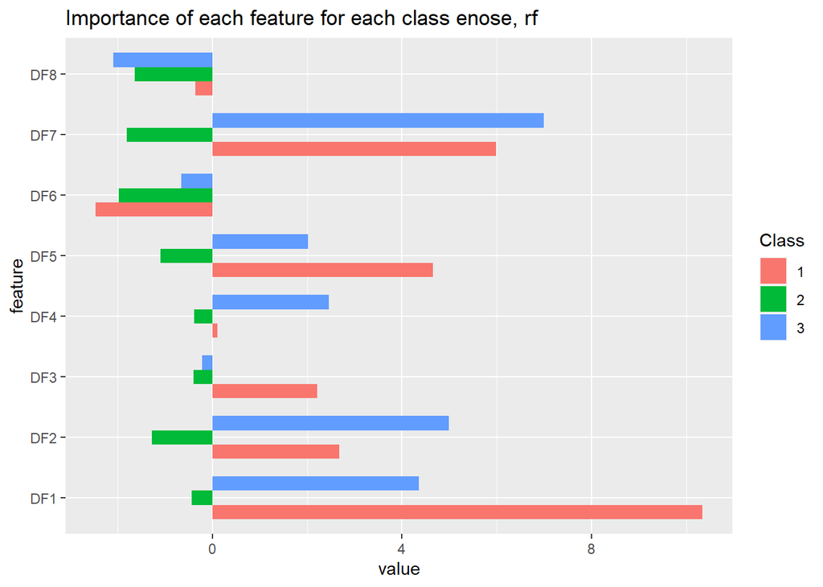

```r
#Variables importance for enose
rf_var_importance_enose <- rf_var_importance(AllData_enose_sens,
                                             AllData_enose_sens$sensory,0.7, 1,
                                             ntree = 200L, mtry = 2L, nodesize = 2L, maxnodes = 20L)
#Importance plot
importance_plot(rf_var_importance_enose, "enose, rf")
```

# Regression

## knn regression

Apply knn regression to HPLC data, to both bacteria types. Train the model to find the best parameters possible.

```r
#Apply tuning to Pseudomonads, HPLC
knn_tuning_HPLC_Pseud <- run_reg_model_tuning(AllData = AllData_HPLC_counts,
                                              perc_pred = .7,
                                              times = 1,
                                              method = "knn",
                                              bacteria = "Pseudomonads",
                                              tuneGrid = expand.grid(k = 1:20), preProcess = c("center","scale"))

#Apply tuning to TVC, HPLC
knn_tuning_HPLC_TVC <- run_reg_model_tuning(AllData = AllData_HPLC_counts,
                                            perc_pred = .7,
                                            times = 1,
                                            method = "knn",
                                            bacteria = "TVC",
                                            tuneGrid = expand.grid(k = 1:20), preProcess = c("center","scale"))

#Display if preprocessing is necessary
knn_tuning_HPLC_Pseud$preProcess
```

```
## [1] TRUE
```

```r
knn_tuning_HPLC_TVC$preProcess
```

```
## [1] TRUE
```

```r
#Display best tunings
knn_tuning_HPLC_Pseud$model.fit$bestTune
```

```
##   k
## 4 4
```

```r
knn_tuning_HPLC_TVC$model.fit$bestTune
```

```
##   k
## 2 2
```

Apply knn tuning to both bacteria types for enose data

```r
#Apply tuning to Pseudomonads, HPLC
knn_tuning_enose_Pseud <- run_reg_model_tuning(AllData = AllData_enose_counts,
                                               perc_pred = .7,
                                               times = 1,
                                               method = "knn",
                                               bacteria = "Pseudomonads",
                                               tuneGrid = expand.grid(k = 1:20), preProcess = c("center","scale"))

#Apply tuning to TVC, HPLC
knn_tuning_enose_TVC <- run_reg_model_tuning(AllData = AllData_enose_counts,
                                             perc_pred = .7,
                                             times = 1,
                                             method = "knn",
                                             bacteria = "TVC",
                                             tuneGrid = expand.grid(k = 1:20),
                                             preProcess = c("center","scale"))

knn_tuning_enose_Pseud$preProcess
```

```
## [1] TRUE
```

```r
knn_tuning_enose_TVC$preProcess
```

```
## [1] TRUE
```

```r
#Display best tunings
knn_tuning_enose_Pseud$model.fit$bestTune
```

```
##   k
## 9 9
```

```r
knn_tuning_enose_TVC$model.fit$bestTune
```

```
##   k
## 5 5
```

Apply the tuned knn model to HPLC, for TVC and for 100 iteration

```r
knn_HPLC_TVC <- run_reg_model_iteration(AllData = AllData_HPLC_counts,
                                        perc_pred = .7,
                                        times = 100,
                                        method = "knn",
                                        bacteria = "TVC",
                                        tuneGrid = expand.grid(k = 1:20),
                                        preProcess = c("center","scale"))
#Mean of RMSE for 100 iterations
knn_HPLC_TVC$mean_RMSE
```

```
## [1] 0.9580908
```

```r
knn_HPLC_TVC$sd_RMSE
```

```
## [1] 0.2483905
```

```r
knn_HPLC_TVC$CI_RMSE
```

```
##     upper      mean     lower
## 1.0073769 0.9580908 0.9088047
```

Plot observed against predicted data for knn, HPLC, TVC

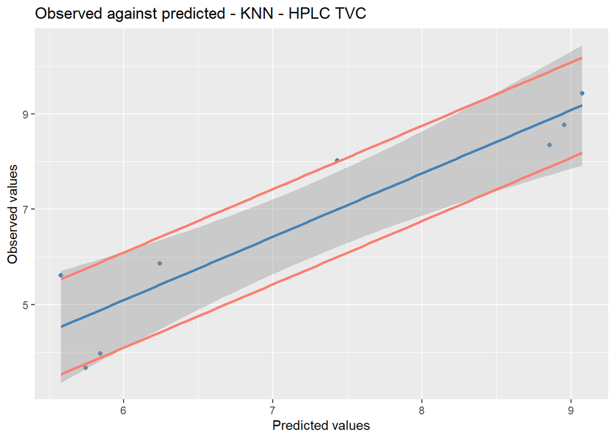

```r
plt <- plot_obs_pred(knn_HPLC_TVC$observed,
                     knn_HPLC_TVC$predict.model,
                     "Observed against predicted - KNN - HPLC TVC")
plt
```

knn model to HPLC, Pseudomonads, 100 iterations

```r
knn_reg_HPLC_Pseudo <- run_reg_model_iteration(AllData = AllData_HPLC_counts,
                                               perc_pred = .7,
                                               times = 100,
                                               method = "knn",
                                               bacteria = "Pseudomonads",
                                               tuneGrid = expand.grid(k = 1:20),
                                               preProcess = c("center","scale"))
#Mean of RMSE for 100 iterations
knn_reg_HPLC_Pseudo$mean_RMSE
```

```
## [1] 1.275811
```

```r
#sd of RMSE
knn_reg_HPLC_Pseudo$sd_RMSE
```

```
## [1] 0.2892798
```

```r
#95% CI of RMSE
knn_reg_HPLC_Pseudo$CI_RMSE
```

```
##    upper     mean    lower
## 1.333210 1.275811 1.218411
```

Plot observed against predicted data for knn, HPLC, Pseudomonads

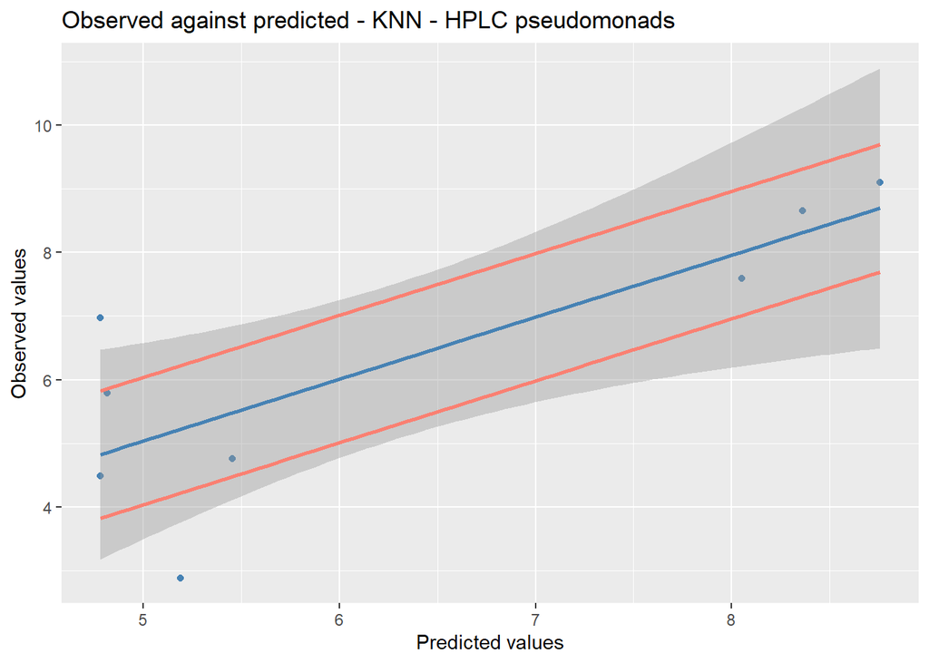

```r
plt <- plot_obs_pred(knn_reg_HPLC_Pseudo$observed,
                     knn_reg_HPLC_Pseudo$predict.model,
                     "Observed against predicted - KNN - HPLC pseudomonads")
plt
```

knn model to enose, TVC, 100 iterations

```r
knn_reg_enose_TVC <- run_reg_model_iteration(AllData = AllData_enose_counts,
                                             perc_pred = .7,
                                             times = 100,
                                             method = "knn",
                                             bacteria = "TVC",
                                             tuneGrid = expand.grid(k = 1:20),
                                             preProcess = c("center","scale"))

#Mean of RMSE for 100 iterations
knn_reg_enose_TVC$mean_RMSE
```

```
## [1] 1.028802
```

```r
#sd of RMSE
knn_reg_enose_TVC$sd_RMSE
```

```
## [1] 0.2677677
```

```r
#95% of RMSE
knn_reg_enose_TVC$CI_RMSE
```

```
##     upper      mean     lower
## 1.0819326 1.0288016 0.9756707
```

Plot observed against predicted data for knn, enose, TVC

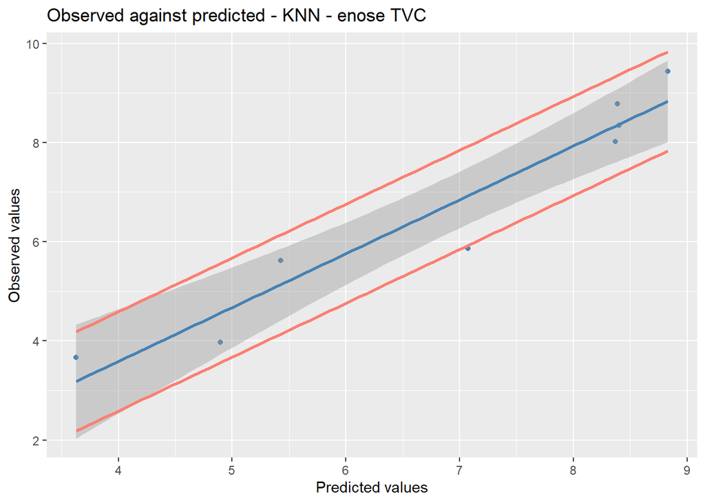

```r
plt <- plot_obs_pred(knn_reg_enose_TVC$observed,
                     knn_reg_enose_TVC$predict.model,
                     "Observed against predicted - KNN - enose TVC")
plt
```

knn model to enose, Pseudomonads, 100 iterations

```r
knn_reg_enose_Pseudo <- run_reg_model_iteration(AllData = AllData_enose_counts,
                                                perc_pred = .7,
                                                times = 100,
                                                method = "knn",
                                                bacteria = "Pseudomonads",
                                                tuneGrid = expand.grid(k = 1:20),
                                                preProcess = c("center","scale"))
#Mean of RMSE for 100 iterations
knn_reg_enose_Pseudo$mean_RMSE
```

```
## [1] 1.282834
```

```r
#sd of RMSE
knn_reg_enose_Pseudo$sd_RMSE
```

```
## [1] 0.2443997
```

```r
#95% CI of RMSE
knn_reg_enose_Pseudo$CI_RMSE
```

```
##    upper     mean    lower
## 1.331329 1.282834 1.234340
```

Plot observed against predicted data for knn, enose, pseudomonads

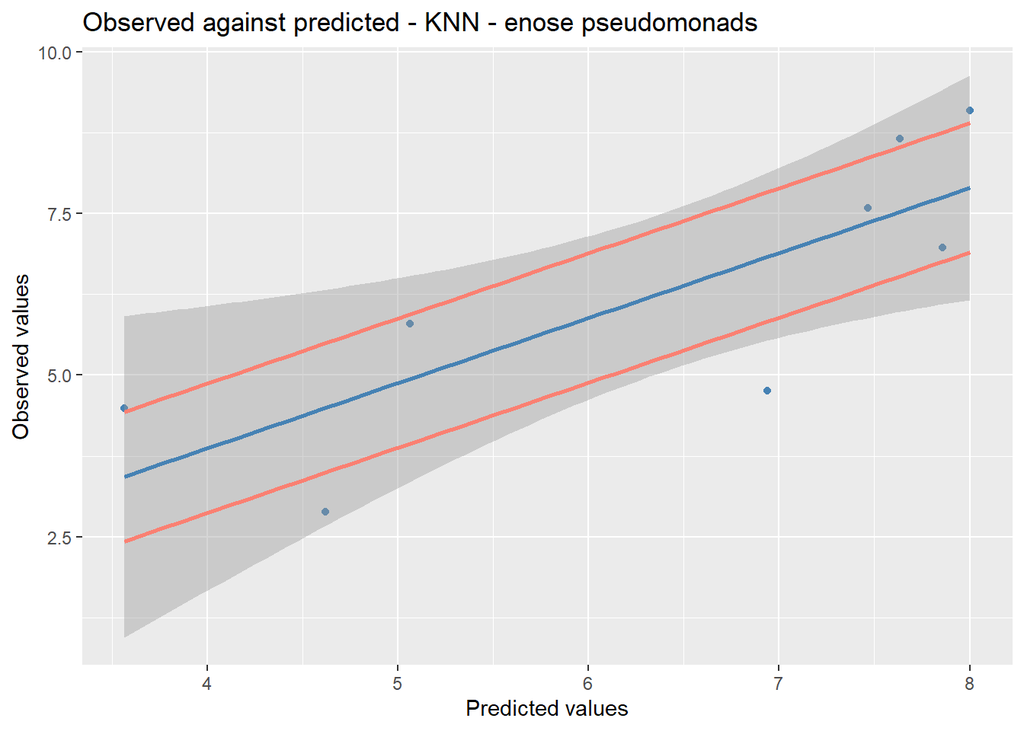

```r
plt <- plot_obs_pred(knn_reg_enose_Pseudo$observed,
                   knn_reg_enose_Pseudo$predict.model,
                  "Observed against predicted - KNN - enose pseudomonads")
plt
```

## Random forest regression

For HPLC, apply random forest (rf) regression, tuning for parameter mtry #Apply tuning to Pseudomonads, HPLC

```r
rf_tuning_HPLC_Pseud <- run_reg_model_tuning(AllData = AllData_HPLC_counts,
                                             perc_pred = .7,
                                             times = 1,
                                             method = "rf",
                                             bacteria = "Pseudomonads",
                                             tuneGrid = expand.grid(mtry = 2:19),
                                             preProcess = c("center","scale"))

#Apply tuning to TVC, HPLC
rf_tuning_HPLC_TVC <- run_reg_model_tuning(AllData = AllData_HPLC_counts,
                                           perc_pred = .7,
                                           times = 1,
                                           method = "rf",
                                           bacteria = "TVC",
                                           tuneGrid = expand.grid(mtry = 2:19),
                                           preProcess = c("center","scale"))

#Display if preprocessing is necessary
rf_tuning_HPLC_Pseud$preProcess
```

```
## [1] FALSE
```

```r
rf_tuning_HPLC_TVC$preProcess
```

```
## [1] FALSE
```

```r
#Display best tunings
rf_tuning_HPLC_Pseud$model.fit$bestTune
```

```
##    mtry
## 18   19
```

```r
rf_tuning_HPLC_TVC$model.fit$bestTune
```

```
##    mtry
## 12   13
```

Apply rf tuning to both bacteria types for enose data

```r
#Apply tuning to Pseudomonads, HPLC
rf_tuning_enose_Pseud <- run_reg_model_tuning(AllData = AllData_enose_counts,
                                              perc_pred = .7,
                                              times = 1,
                                              method = "rf",
                                              bacteria = "Pseudomonads",
                                              tuneGrid = expand.grid(mtry = 2:9),
                                              preProcess = c("center","scale"))

#Apply tuning to TVC, HPLC
rf_tuning_enose_TVC <- run_reg_model_tuning(AllData = AllData_enose_counts,
                                            perc_pred = .7,
                                            times = 1,
                                            method = "rf",
                                            bacteria = "TVC",
                                            tuneGrid = expand.grid(mtry = 2:9),
                                            preProcess = c("center","scale"))

rf_tuning_enose_Pseud$preProcess
```

```
## [1] FALSE
```

```r
rf_tuning_enose_TVC$preProcess
```

```
## [1] TRUE
```

```r
#Display best tunings
rf_tuning_enose_Pseud$model.fit$bestTune
```

```
##   mtry
## 8    9
```

```r
rf_tuning_enose_TVC$model.fit$bestTune
```

```
##   mtry
## 7    8
```

### 100 iterations

```r
run_rf_HPLC_TVC <- run_reg_model_iteration(AllData = AllData_HPLC_counts,
                                           perc_pred = .7,
                                           times = 100,
                                           method = "knn",
                                           bacteria = "TVC",
                                           tuneGrid = expand.grid(k = 2:19),
                                           preProcess = c("center","scale"))
#Mean of RMSE for 100 iterations
run_rf_HPLC_TVC$mean_RMSE
```

```
## [1] 0.9540745
```

```r
#sd of RMSE
run_rf_HPLC_TVC$sd_RMSE
```

```
## [1] 0.2020436
```

```r
#CI of RMSE
run_rf_HPLC_TVC$CI_RMSE
```

```
##     upper      mean     lower
## 0.9941643 0.9540745 0.9139846
```

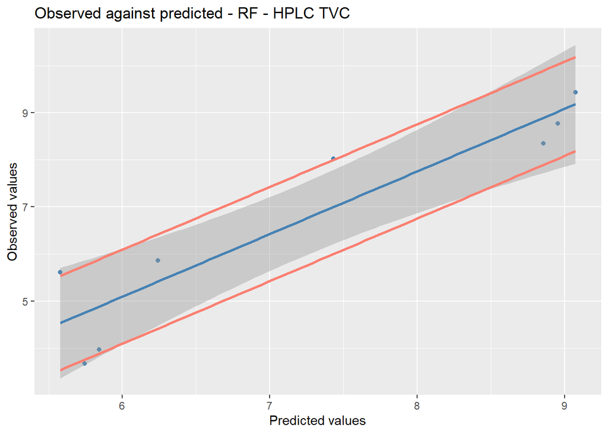

```r
plt <- plot_obs_pred(run_rf_HPLC_TVC$observed,
                     run_rf_HPLC_TVC$predict.model,
                     "Observed against predicted - RF - HPLC TVC")
plt
```

```r
run_rf_HPLC_Pseudo <- run_reg_model_iteration(AllData = AllData_HPLC_counts,
                                              perc_pred = .7,
                                              times = 100,
                                              method = "knn",
                                              bacteria = "Pseudomonads",
                                              tuneGrid = expand.grid(k = 2:19),
                                              preProcess = c("center","scale"))
#Mean of RMSE for 100 iterations
run_rf_HPLC_Pseudo$mean_RMSE
```

```
## [1] 1.230158
```

```r
#sd of RMSE
run_rf_HPLC_Pseudo$sd_RMSE
```

```
## [1] 0.3037688
```

```r
#CI of RMSE
run_rf_HPLC_Pseudo$CI_RMSE
```

```
##    upper     mean    lower
## 1.290432 1.230158 1.169883
```

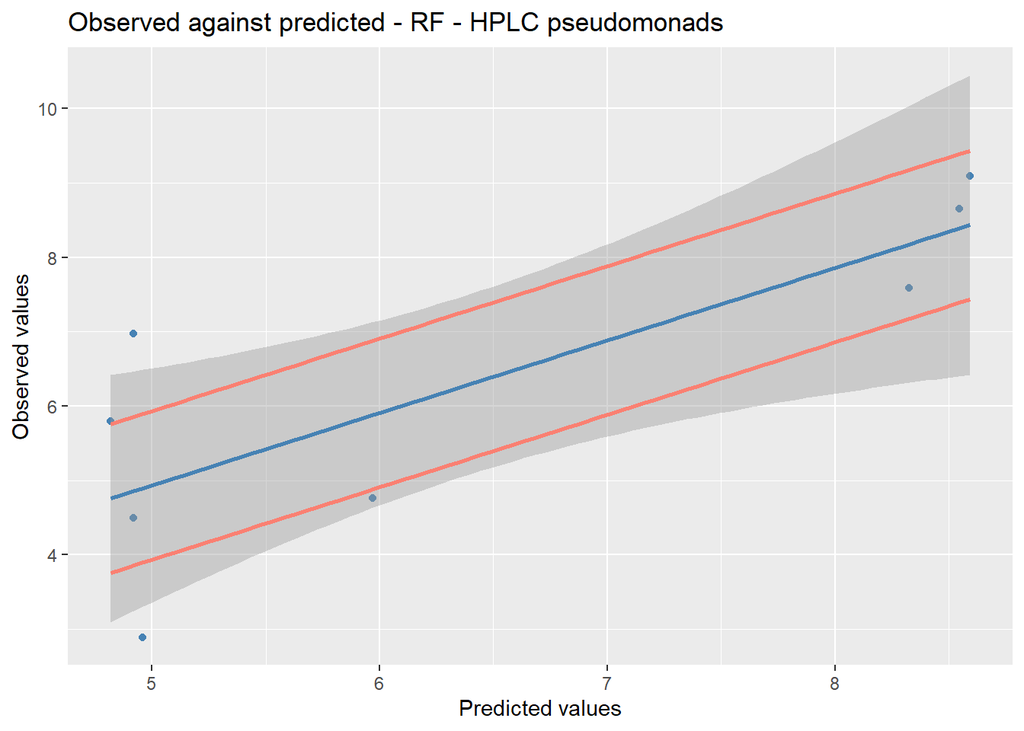

```r
plt <- plot_obs_pred(run_rf_HPLC_Pseudo$observed,
                     run_rf_HPLC_Pseudo$predict.model,
                     "Observed against predicted - RF - HPLC pseudomonads")
plt
```

```r
run_rf_enose_TVC <- run_reg_model_iteration(AllData = AllData_enose_counts,
                                            perc_pred = .7,
                                            times = 100,
                                            method = "knn",
                                            bacteria = "TVC",
                                            tuneGrid = expand.grid(k = 2:9),
                                            preProcess = c("center","scale"))
#Mean of RMSE for 100 iterations
run_rf_enose_TVC$mean_RMSE
```

```
## [1] 1.008827
```

```r
#sd of RMSE
run_rf_enose_TVC$sd_RMSE
```

```
## [1] 0.2707873
```

```r
#CI of RMSE
run_rf_enose_TVC$CI_RMSE
```

```
##     upper      mean     lower
## 1.0625566 1.0088265 0.9550965
```

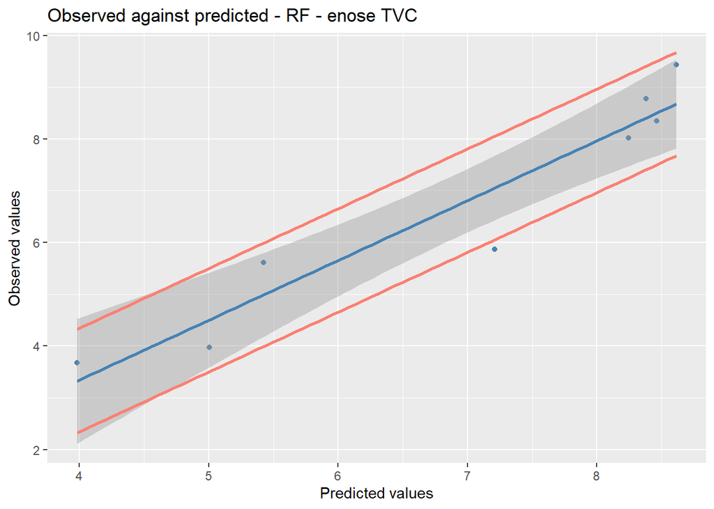

```r
plt <- plot_obs_pred(run_rf_enose_TVC$observed,
                     run_rf_enose_TVC$predict.model,
                     "Observed against predicted - RF - enose TVC")
plt
```

```r
run_rf_enose_Pseudo <- run_reg_model_iteration(AllData = AllData_enose_counts,
                                               perc_pred = .7,
                                               times = 100,
                                               method = "knn",
                                               bacteria = "Pseudomonads",
                                               tuneGrid = expand.grid(k = 2:9),
                                               preProcess = c("center","scale"))
#Mean of RMSE for 100 iterations
run_rf_enose_Pseudo$mean_RMSE
```

```
## [1] 1.29328
```

```r
#sd of RMSE
run_rf_enose_Pseudo$sd_RMSE
```

```
## [1] 0.2656054
```

```r
#CI of RMSE
run_rf_enose_Pseudo$CI_RMSE
```

```
##    upper     mean    lower
## 1.345982 1.293280 1.240579
```

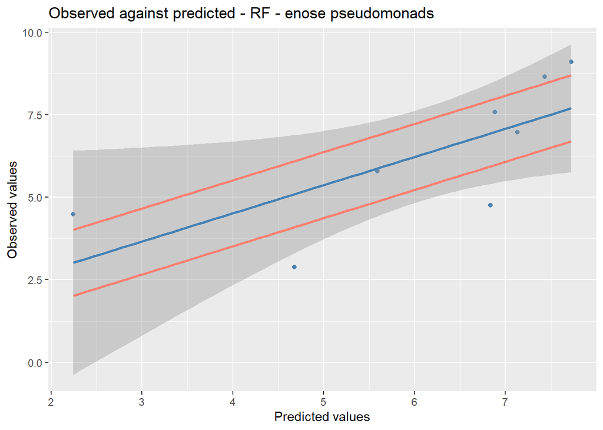

```r
plt <- plot_obs_pred(run_rf_enose_Pseudo$observed,
                     run_rf_enose_Pseudo$predict.model,
                     "Observed against predicted - RF - enose pseudomonads")
plt
```

## PLS regression

Apply partial least regression to HPLC data, to both bacteria types. Optimise, train and test the model.

### Tuning

```r
#Apply tuning to Pseudomonads, HPLC
plsr_tuning_HPLC_Pseud <- run_reg_model_tuning(AllData = AllData_HPLC_counts, perc_pred = .7, times = 1, method = "pls", bacteria = "Pseudomonads",
                        tuneGrid = expand.grid(ncomp = 1:20), preProcess = c("center","scale"))

#Apply tuning to TVC, HPLC
plsr_tuning_HPLC_TVC <- run_reg_model_tuning(AllData = AllData_HPLC_counts, perc_pred = .7, times = 1, method = "pls", bacteria = "TVC",
                        tuneGrid = expand.grid(ncomp = 1:20), preProcess = c("center","scale"))

#Display if preprocessing is necessary
plsr_tuning_HPLC_Pseud$preProcess
```

```
## [1] TRUE
```

```r
plsr_tuning_HPLC_TVC$preProcess
```

```
## [1] FALSE
```

```r
#Display best tunings
plsr_tuning_HPLC_Pseud$model.fit$bestTune
```

```
##   ncomp
## 4     4
```

```r
plsr_tuning_HPLC_TVC$model.fit$bestTune
```

```
##   ncomp
## 8     8
```

Apply pls tuning to both bacteria types for enose data

```r
#Apply tuning to Pseudomonads, HPLC
pls_tuning_enose_Pseud <- run_reg_model_tuning(AllData = AllData_enose_counts, perc_pred = .7, times = 1, method = "pls", bacteria = "Pseudomonads",
                        tuneGrid = expand.grid(ncomp = 1:10), preProcess = c("center","scale"))

#Apply tuning to TVC, HPLC
pls_tuning_enose_TVC <- run_reg_model_tuning(AllData = AllData_enose_counts, perc_pred = .7, times = 1, method = "pls", bacteria = "TVC",
                        tuneGrid = expand.grid(ncomp = 1:10), preProcess = c("center","scale"))

pls_tuning_enose_Pseud$preProcess
```

```
## [1] FALSE
```

```r
pls_tuning_enose_TVC$preProcess
```

```
## [1] FALSE
```

```r
#Display best tunings
pls_tuning_enose_Pseud$model.fit$bestTune
```

```
##   ncomp
## 9     9
```

```r
pls_tuning_enose_TVC$model.fit$bestTune
```

```
##   ncomp
## 9     9
```

Apply the tuned pls model to HPLC, for TVC and for 100 iteration

```r
pls_HPLC_TVC <- run_reg_model_iteration(AllData = AllData_HPLC_counts,
                                        perc_pred = .7,
                                        times = 100,
                                        method = "pls",
                                        bacteria = "TVC",
                                        tuneGrid = expand.grid(ncomp = 1:20),
                                        preProcess = NULL)
#Mean of RMSE for 100 iterations
pls_HPLC_TVC$mean_RMSE
```

```
## [1] 0.9400853
```

```r
pls_HPLC_TVC$sd_RMSE
```

```
## [1] 0.3652988
```

```r
pls_HPLC_TVC$CI_RMSE
```

```
##     upper      mean     lower
## 1.0125685 0.9400853 0.8676021
```

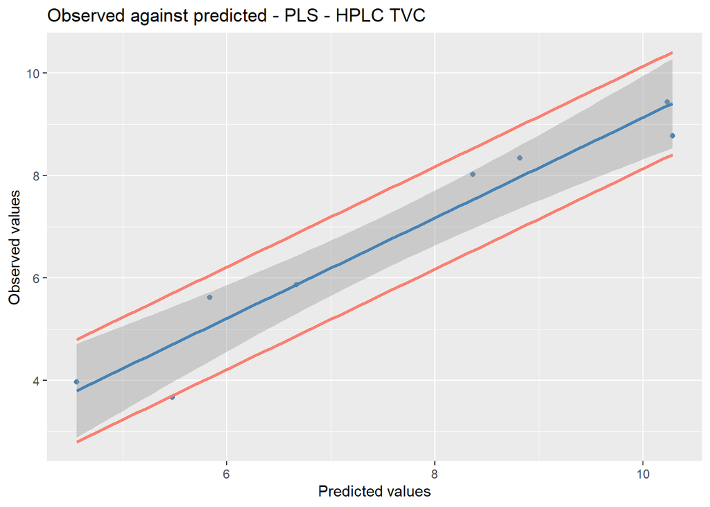

```r
plt <- plot_obs_pred(pls_HPLC_TVC$observed,
                     pls_HPLC_TVC$predict.model,
                     "Observed against predicted - PLS - HPLC TVC")
plt
```

pls model to HPLC, Pseudomonads, 100 iterations

```r
pls_reg_HPLC_Pseudo <- run_reg_model_iteration(AllData = AllData_HPLC_counts,
                                               perc_pred = .7,
                                               times = 100,
                                               method = "pls",
                                               bacteria = "Pseudomonads",
                                               tuneGrid = expand.grid(ncomp = 1:20),
                                               preProcess = NULL)
#Mean of RMSE for 100 iterations
pls_reg_HPLC_Pseudo$mean_RMSE
```

```
## [1] 1.253126
```

```r
#sd of RMSE
pls_reg_HPLC_Pseudo$sd_RMSE
```

```
## [1] 0.4071671
```

```r
#95% CI of RMSE
pls_reg_HPLC_Pseudo$CI_RMSE
```

```
##    upper     mean    lower
## 1.333917 1.253126 1.172335
```

Plot observed against predicted data for pls, HPLC, Pseudomonads

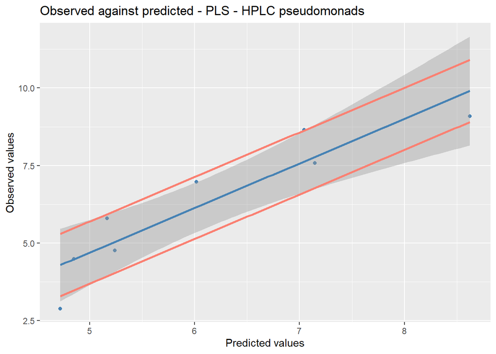

```r
plt <- plot_obs_pred(pls_reg_HPLC_Pseudo$observed,
                     pls_reg_HPLC_Pseudo$predict.model,
                     "Observed against predicted - PLS - HPLC pseudomonads")
plt
```

pls model to enose, TVC, 100 iterations

```r
pls_reg_enose_TVC <- run_reg_model_iteration(AllData = AllData_enose_counts,
                                             perc_pred = .7,
                                             times = 100,
                                             method = "pls",
                                             bacteria = "TVC",
                                             tuneGrid = expand.grid(ncomp = 1:10),
                                             preProcess = NULL)

#Mean of RMSE for 100 iterations
pls_reg_enose_TVC$mean_RMSE
```

```
## [1] 0.9047395
```

```r
#sd of RMSE
pls_reg_enose_TVC$sd_RMSE
```

```
## [1] 0.3106246
```

```r
#95% of RMSE
pls_reg_enose_TVC$CI_RMSE
```

```
##     upper      mean     lower
## 0.9663742 0.9047395 0.8431048
```

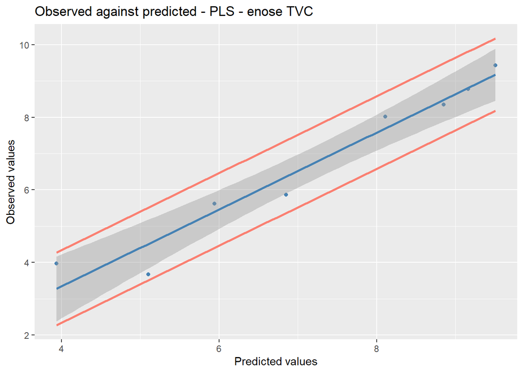

```r
plt <- plot_obs_pred(pls_reg_enose_TVC$observed,
                     pls_reg_enose_TVC$predict.model,
                     "Observed against predicted - PLS - enose TVC")
plt
```

pls model to enose, Pseudomonads, 100 iterations

```r
pls_reg_enose_Pseudo <- run_reg_model_iteration(AllData = AllData_enose_counts,
                                                perc_pred = .7,
                                                times = 100,
                                                method = "pls",
                                                bacteria = "Pseudomonads",
                                                tuneGrid = expand.grid(ncomp = 1:10),
                                                preProcess = NULL)
#Mean of RMSE for 100 iterations
pls_reg_enose_Pseudo$mean_RMSE
```

```
## [1] 1.127023
```

```r
#sd of RMSE
pls_reg_enose_Pseudo$sd_RMSE
```

```
## [1] 0.3712804
```

```r
#95% CI of RMSE
pls_reg_enose_Pseudo$CI_RMSE
```

```
##    upper     mean    lower
## 1.200694 1.127023 1.053353
```

Plot observed against predicted data for pls, enose, pseudomonads

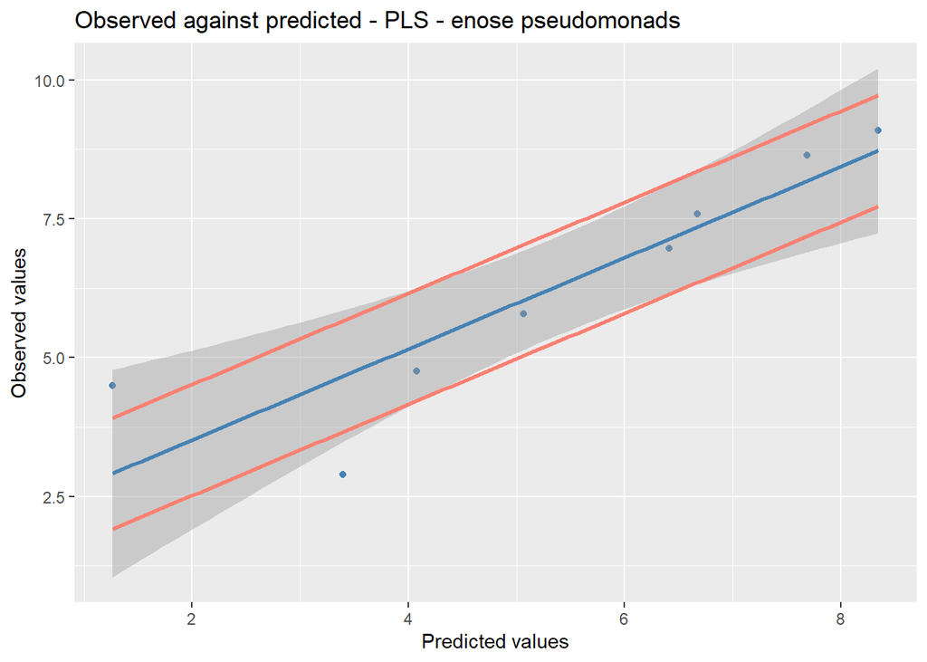

```r
plt <- plot_obs_pred(pls_reg_enose_Pseudo$observed,
                   pls_reg_enose_Pseudo$predict.model,
                  "Observed against predicted - PLS - enose pseudomonads")
plt
```